# Solution 05

Jannik Buhr

16/11/2021

## Setup

```r
library(tidyverse)

theme_set(theme_minimal())
```

## A Fair Coin

We have a regular old coin and flip it 100 times. Given a significance threshold $\alpha$ of 0.05, with what probability do we (mistakenly) reject the null hypothesis i.e. conclude that the coin is not fair even though it is? Can you show this with a simulation? As a tip I can tell you that due to the vectorized nature of the functions involved you won’t need a `map` or loop. The shortest version I could think of uses only 3 functions.

The very small solution:

```r
alpha <- 0.05
heads <- rbinom(n = 10000, size = 100, prob = 0.5)
ps <- pbinom(q = heads, size = 100, prob = 0.5)
mean(ps <= alpha)
```

```
## [1] 0.0473
```

### Some explanatory plots

By sampling at random from the binomial distribution:

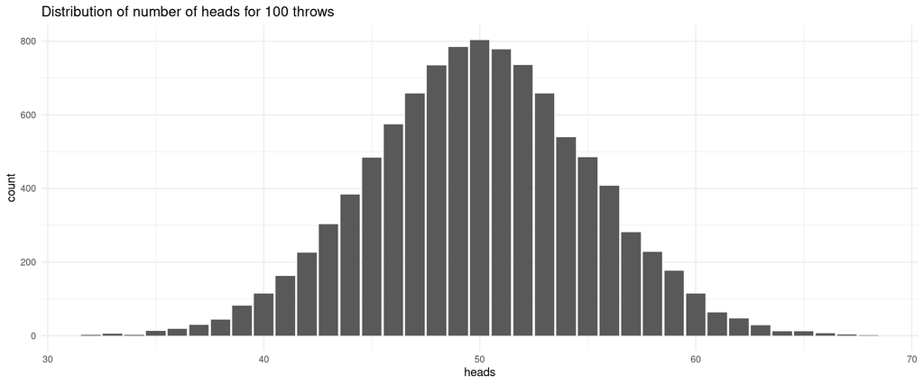

```r
tibble(heads) %>%
  ggplot(aes(heads)) +
  geom_bar() +
  labs(title = "Distribution of number of heads for 100 throws")
```

By using the actual probability density function:

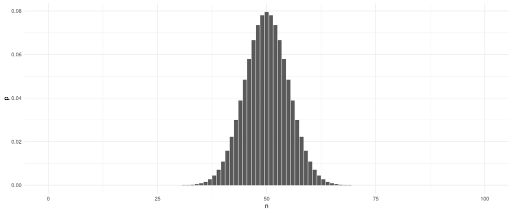

```r
tibble(
  n = 0:100,
  p = dbinom(x = n, size = 100, prob = 0.5)
) %>%
  ggplot(aes(n, p)) +
  geom_col()
```

The probability

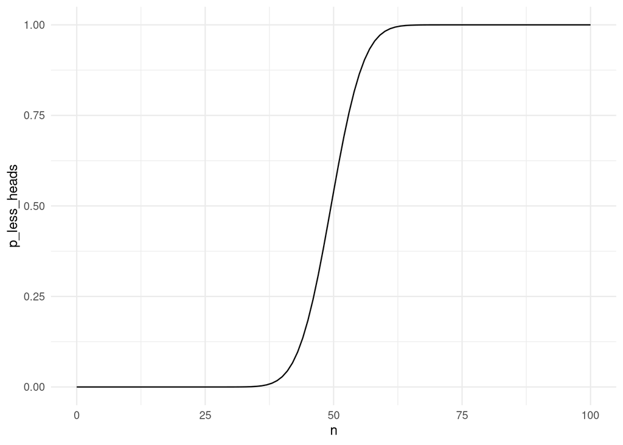

```r
tibble(
  n = 0:100,
  p_less_heads = pbinom(q = n, size = 100, prob = 0.5)
) %>%
  ggplot(aes(n, p_less_heads)) +
  geom_line()
```

## An Unfair Game

We are playing a game where you have to roll the most sixes in order to win. Someone is trying to fool us and is using a loaded die. The die is manipulated such that the chance of rolling a six is 35% instead of the usual 1/6. At the same significance threshold as above, what is the chance of us rejecting the null hypothesis (= a fair die) and thus concluding correctly that we are being tricked after rolling the die 20 times? You will have to run a simulation here again.

```r
sixes <- rbinom(n = 10000, size = 20, prob = 0.35)
ps <- pbinom(q = sixes - 1, size = 20, prob = 1/6, lower.tail = FALSE)
mean(ps <= alpha)
```

```
## [1] 0.5887
```

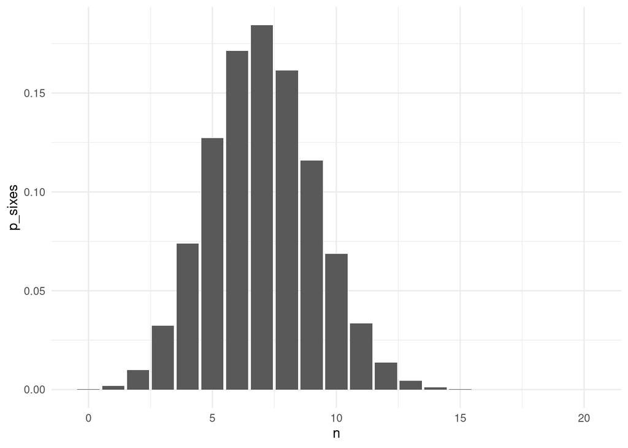

```r
tibble(
  n = 0:20,
  p_sixes = dbinom(0:20, size = 20, prob = 0.35)
) %>%
  ggplot(aes(n, p_sixes)) +
  geom_col()
```

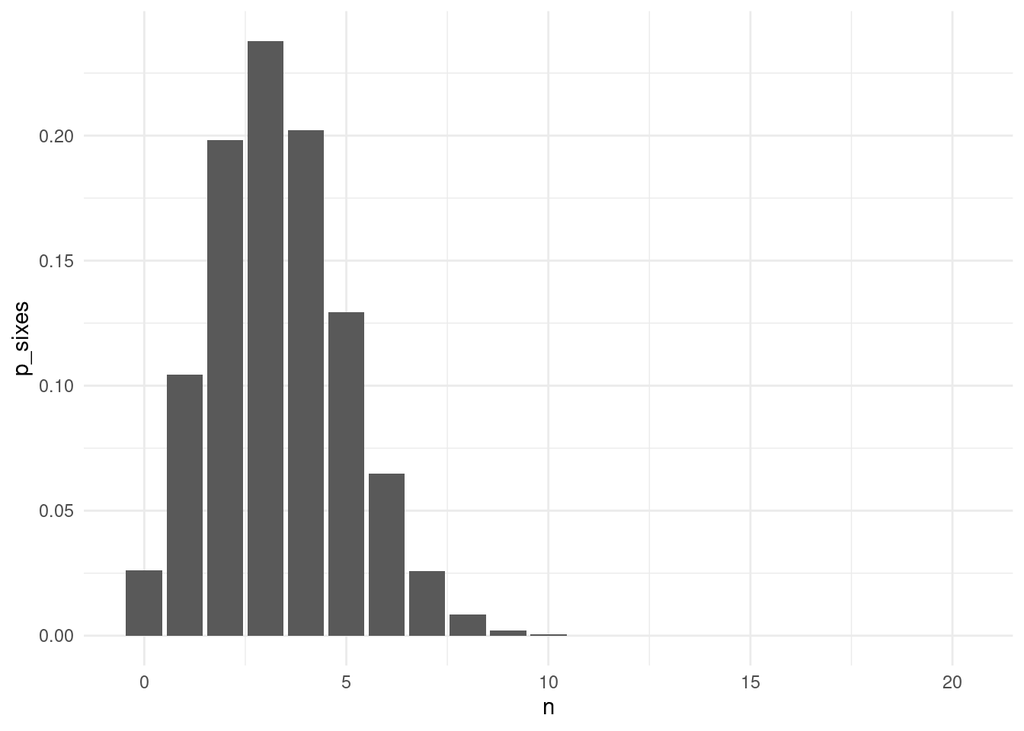

```r
tibble(
  n = 0:20,
  p_sixes = dbinom(0:20, size = 20, prob = 1/6)
) %>%
  ggplot(aes(n, p_sixes)) +
  geom_col()
```

```r
sixes <- rbinom(100000, size = 20, prob = 0.35)
ps <- pbinom(q = sixes - 1, size = 20, prob = 1/6, lower.tail = FALSE)
mean(ps <= alpha)
```

```
## [1] 0.5859
```

## Discovering a new Distribution

The binomial distribution was concerned with sampling with replacement (you can get head or tails any number of times without using up the coin). In this exercise you will explore sampling **without** replacement. The common model for this is an urn with two different colored balls in it. The resulting distribution is called the **hypergeometric distribution** and the corresponding R functions are `<r/d/p/q>hyper`

- Imagine you are a zoo manager.
  - We got a gift from another zoo! It consists of 8 red pandas and 2 giant pandas. What is the probability that they end up properly separated, if we randomly take 8 animals, put them in one enclosure and put the rest in another?
  - Our penguin colony hatched eggs and we have a bunch of newcomers. We have have 15 males and 10 females. If we look at a random subset of 12 penguins, what does the distribution of the number of males look like? Which number is most likely? How likely is it, to get at least 9 males in the sample?

Pandas

```r
scales::percent_format(accuracy = 0.01)(dhyper(x = 8, m = 8, n = 2, k = 8))
```

```
## [1] "2.22%"
```

Penguins

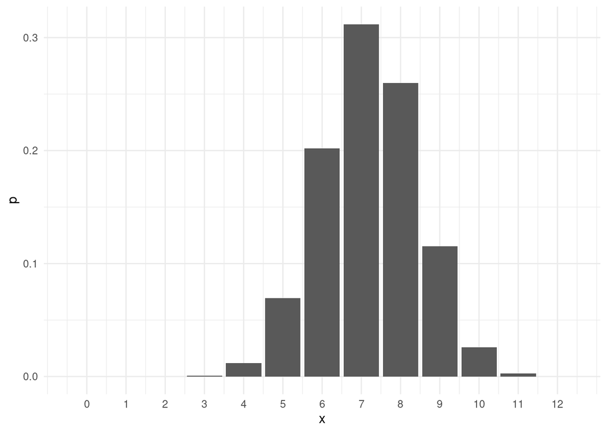

```r
tibble(
  x = 0:12,
  p = dhyper(x = x, m = 15, n = 10, k = 12)
) %>%
  ggplot(aes(x, p)) +
  geom_col() +
  scale_x_continuous(breaks = 0:12)
```

```r
res <- phyper(q = 9 - 1, m = 15, n = 10, k = 12, lower.tail = FALSE)
scales::percent_format(accuracy = 1e-1)(res)
```

```
## [1] "14.4%"
```